# MachineLearningProject

KS

Friday, January 23, 2015

#### Introduction

This is a project for the Machine learning course in Data Science offered on coursera.org by John Hopkins Bloomberg School of Public Health. The goal of this project is to predict the manner in which they did the exercise. This is the "classe" variable in the training set. We will use any of the other variables to predict with. here I describe how I built my model, how I used cross validation, what I think the expected out of sample error is, and why I made the choices I did. I will also use my prediction model to predict 20 different test cases.

#### Exploratory Analysis & Tidying Data

There are 2 datasets here to start with **[pml_train(pml-testing.csv)](https://d396qusza40orc.cloudfront.net/predmachlearn/pml-training.csv)** and **[pml_test(pml-training.csv)](https://d396qusza40orc.cloudfront.net/predmachlearn/pml-testing.csv)**. Both have 160 variables alot of which is NAs and due to the lack of a codebook I am unable to determine what these variables are. The variable names do give an idea of what they might be. One main difference between the training and testing dataset is the variable **classe** is in training and it is called **problem_id** in the testing dataset. It is our objective here to predict the value (A,B,C,D,E) of the testing dataset, by building a predictive model using the training dataset.

After numerous attempts of tidying the data, I finally decided to find all the columns in the test data that do not have any NAs and then use that to get them columns from my train dataset. this is the data set I used and I build my model based on this:

**NOTE: Anything with the variables mf1,mf2 and ,mf3 will be commented out as they have not been declared as this report takes too long to run. Please see the Functions.R file for all the code used here.**

```r
dim(pml_train_NoNAs) # this is the train dataset with columns that do not have any NAs in the columns from the test dataset
```

```
## [1] 19622    57
```

```r
#mf1<-train(classe ~.,data=pml_train_NoNAs, method="lda") # comented out here as takes a while to run
```

My first model above, **mf1**, gave me an accuracy of 99% which sounded to good to be true, which proved so as I done my prediction with this model on the test set and got all “A”s which suggested to me that I might be overfitting.

```r
#predicMLProject(pml_test,mf1)  # comented out here as takes a while to run
#[1] "A" "A" "A" "A" "A" "A" "A" "A" "A" "A" "A" "A" "A" "A" "A" "A" "A" "A" "A" "A"  ## all "A"s answer from model mf1
```

### Fine Tuning the model

Given the above model was possibly overfitting here I plan to do some fine tuning. Having a further looked at the data I notieced the X variable to have an interesting pattern and felt it should be removed for my model:

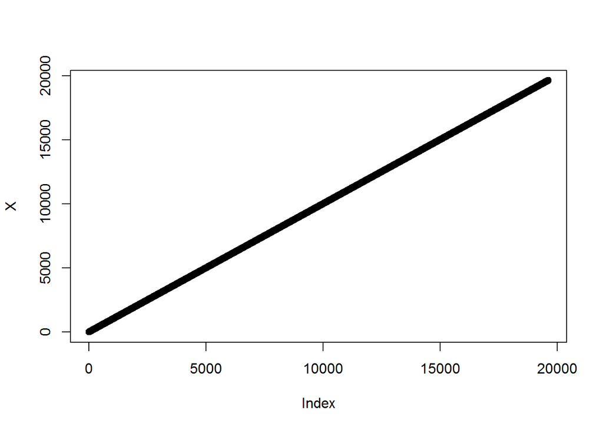

**Figure1:** This is a look at the **X** variable in the dataset.

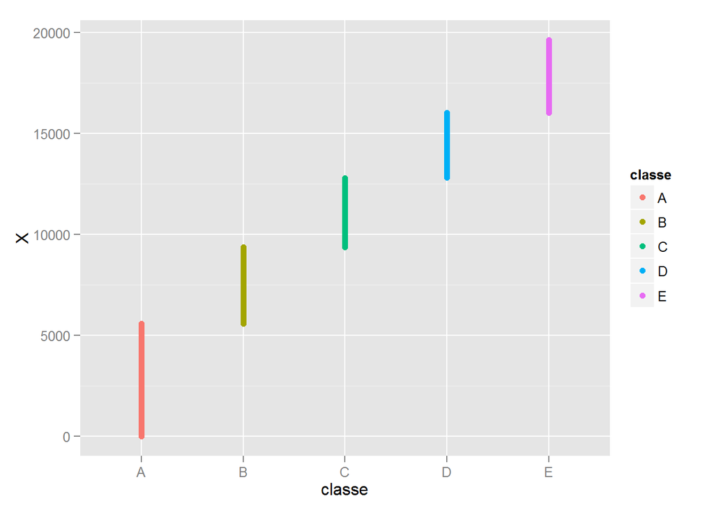

**Figure2:** This is a look at the **X** variable in the dataset cloloured by the **classe** variable.

So I then decided to remove 3 columns and build a new model: **X** as explained above and these two, **raw_timestamp_part_1** and **raw_timestamp_part_2** as this would not help the prediction model.

```r
dim(pml_train_NoNAs_mf2)
```

```
## [1] 19622    54
```

```r
#`mf2<-train(classe ~.,data=pml_train_NoNAs_mf2, method="lda")`# comented out here as takes a while to run
```

This was a better model, in that it gave me varied predictions of A, B, C, D or E. But it still only gave me an accuracy of 71%.This was reflected in the second part of the project where my prediction model was to predict the 20 different test cases. Here I only got 14 out of 20 right (14/20=0.7).

```r
#predicMLProject(pml_test,mf2) # comented out here as contains the variable mf2 which is not declared
#[1] "B" "A" "B" "A" "A" "E" "D" "D" "A" "A" "D" "A" "E" "A" "B" "A" "A" "B" "B" "B"`
```

Now here I would like to explain how I improve the accuracy of my model, by various methods, if time pemits.

- Finding and removing non varying variables as these do not add to the model.
- use other models other than **lda**
- Do some crossvalidation
- Do some preProcessing

Firstly I will try another model, unsing **randomForest**, as opposed to **lda**.

```r
#mf3<-train(classe ~.,data=pml_train_NoNAs_mf2, method="rf") # comented out here as takes a while to run
#predicMLProject(pml_test,mf3) comented out here as contains the variable mf3 which is not declared
#[1] "B" "A" "B" "A" "A" "E" "D" "B" "A" "A" "B" "C" "B" "A" "E" "E" "A" "B" "B" "B"  # mf3 answers
```

This gives an Accuracy of 99% and on submitting these in my 20 test cases I get 19 out of 20 right, which is very close to 100%.

Unfortunately, I did not get time to further improve my accuracy. This is something I would like to revisit.

### Reference

Please see here for more details on the WLE dataset

Velloso, E.; Bulling, A.; Gellersen, H.; Ugulino, W.; Fuks, H. [Qualitative Activity Recognition of Weight Lifting Exercises](http://groupware.les.inf.puc-rio.br/work.jsf?p1=11201). Proceedings of 4th International Conference in Cooperation with SIGCHI (Augmented Human ’13) . Stuttgart, Germany: ACM SIGCHI, 2013.

Read more: http://groupware.les.inf.puc-rio.br/har#ixzz3O5zG5ZD3